# survival lecture 4

Steve Simon

April 8, 2018

Lecture 4. Model fitting and diagnostics for the Cox model. In this lecture, you will work with more complex forms of the Cox model with multiple predictor variables. You’ll include covariates in the Cox model to produce risk adjusted survival curves. You will also assess the underlying assumptions of the Cox model, particularly the assumption of proportional hazards.

This file does not need any special libraries other than the ones listed below. Many of the data sets in this program use data from Hosmer, Lemeshow, and May. I made one minor change, however, which was to force all the variable names to lower case.

```r
library(broom)
library(dplyr)
```

```r
library(ggplot2)
library(magrittr)
library(survival)
library(tidyr)
```

## Cox multivariate regression

Recall that we ran a log rank test for gender using the WHAS100 data file. Let’s calculate a Cox regression model for the same data and compare it to the log rank test.

```r
fn <- "../../data/whas100.RData"
load(fn)
head(whas100)
```

```
##   id  admitdate    foldate los lenfol fstat age gender      bmi  time_yrs
## 1  1 03/13/1995 03/19/1995   4      6  Dead  65   Male 31.38134 0.0164271
## 2  2 01/14/1995 01/23/1996   5    374  Dead  88 Female 22.65790 1.0239562
## 3  3 02/17/1995 10/04/2001   5   2421  Dead  77   Male 27.87892 6.6283368
## 4  4 04/07/1995 07/14/1995   9     98  Dead  81 Female 21.47878 0.2683094
## 5  5 02/09/1995 05/29/1998   4   1205  Dead  78   Male 30.70601 3.2991102
## 6  6 01/16/1995 09/11/2000   7   2065  Dead  82 Female 26.45294 5.6536619
##   age_group
## 1     60-69
## 2      >=80
## 3     70-79
## 4      >=80
## 5     70-79
## 6      >=80
```

```r
fn <- "../../data/whas500.RData"
load(fn)
whas500$time_yrs <- whas500$lenfol/365.25
head(whas500)
```

```
##   id age gender hr sysbp diasbp      bmi cvd afb sho chf av3     miord
## 1  1  83   Male 89   152     78 25.54051  No Yes  No  No  No Recurrent
## 2  2  49   Male 84   120     60 24.02398  No  No  No  No  No     First
## 3  3  70 Female 83   147     88 22.14290  No  No  No  No  No     First
## 4  4  70   Male 65   123     76 26.63187 Yes  No  No Yes  No     First
## 5  5  70   Male 63   135     85 24.41255  No  No  No  No  No     First
## 6  6  70   Male 76    83     54 23.24236 Yes  No  No  No Yes     First
##       mitype year  admitdate    disdate      fdate los dstat lenfol fstat
## 1 Non Q-wave <NA> 01/13/1997 01/18/1997 12/31/2002   5 Alive   2178 Alive
## 2     Q-wave <NA> 01/19/1997 01/24/1997 12/31/2002   5 Alive   2172 Alive
## 3     Q-wave <NA> 01/01/1997 01/06/1997 12/31/2002   5 Alive   2190 Alive
## 4     Q-wave <NA> 02/17/1997 02/27/1997 12/11/1997  10 Alive    297  Dead
## 5     Q-wave <NA> 03/01/1997 03/07/1997 12/31/2002   6 Alive   2131 Alive
## 6 Non Q-wave <NA> 03/11/1997 03/12/1997 03/12/1997   1  Dead      1  Dead
##      time_yrs
## 1 5.963039014
## 2 5.946611910
## 3 5.995893224
## 4 0.813141684
## 5 5.834360027
## 6 0.002737851
```

You should examine your independent variables one at a time before putting them all in a multivariate model.

```r
cox_age <-
  coxph(Surv(time_yrs, fstat=="Dead")~age,
    data=whas500)
summary(cox_age)
```

```
## Call:
## coxph(formula = Surv(time_yrs, fstat == "Dead") ~ age, data = whas500)
##
##   n= 500, number of events= 215
##
##         coef exp(coef) se(coef)     z Pr(>|z|)
## age 0.066339  1.068589 0.006079 10.91   <2e-16 ***
## ---
## Signif. codes:  0 '***' 0.001 '**' 0.01 '*' 0.05 '.' 0.1 ' ' 1
##
##     exp(coef) exp(-coef) lower .95 upper .95
## age     1.069     0.9358     1.056     1.081
##
## Concordance= 0.731  (se = 0.021 )
## Rsquare= 0.247   (max possible= 0.993 )
## Likelihood ratio test= 142.1  on 1 df,   p=0
## Wald test            = 119.1  on 1 df,   p=0
## Score (logrank) test = 126.6  on 1 df,   p=0
```

```r
cox_gender <-
  coxph(Surv(time_yrs, fstat=="Dead")~gender,
    data=whas500)
summary(cox_gender)
```

```
## Call:
## coxph(formula = Surv(time_yrs, fstat == "Dead") ~ gender, data = whas500)
##
##   n= 500, number of events= 215
##
##                coef exp(coef) se(coef)     z Pr(>|z|)
## genderFemale 0.3815    1.4645   0.1376 2.773  0.00556 **
## ---
## Signif. codes:  0 '***' 0.001 '**' 0.01 '*' 0.05 '.' 0.1 ' ' 1
##
##              exp(coef) exp(-coef) lower .95 upper .95
## genderFemale     1.464     0.6828     1.118     1.918
##
## Concordance= 0.542  (se = 0.018 )
## Rsquare= 0.015   (max possible= 0.993 )
## Likelihood ratio test= 7.6  on 1 df,   p=0.005843
## Wald test            = 7.69  on 1 df,   p=0.005555
## Score (logrank) test = 7.78  on 1 df,   p=0.005275
```

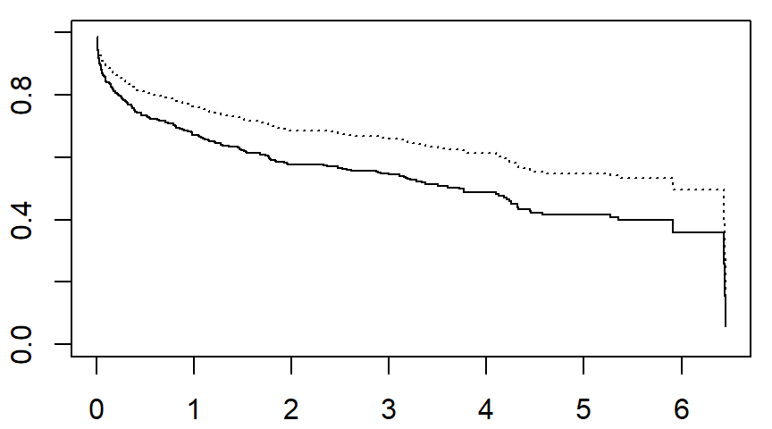

```r
n <- data.frame(gender=factor(1:2, labels=c("Male", "Female")))
cox_predict <- survfit(cox_gender, newdata=n)
par(mar=c(2.1, 2.1, 0.6, 0.6))
plot(
  cox_predict$time,
  cox_predict$surv[, 2],
  type="s", ylim=c(0,1))
lines(
  cox_predict$time,
  cox_predict$surv[, 1],
  type="s", lty="dotted")
```

```r
cox_mv <-
  coxph(Surv(time_yrs, fstat=="Dead")~age+gender,
    data=whas500)
summary(cox_mv)
```

```
## Call:
## coxph(formula = Surv(time_yrs, fstat == "Dead") ~ age + gender,
##     data = whas500)
##
##   n= 500, number of events= 215
##
##                   coef exp(coef)  se(coef)      z Pr(>|z|)
## age           0.066928  1.069218  0.006196 10.802   <2e-16 ***
## genderFemale -0.066285  0.935864  0.140585 -0.471    0.637
## ---
## Signif. codes:  0 '***' 0.001 '**' 0.01 '*' 0.05 '.' 0.1 ' ' 1
##
##              exp(coef) exp(-coef) lower .95 upper .95
## age             1.0692     0.9353    1.0563     1.082
## genderFemale    0.9359     1.0685    0.7105     1.233
##
## Concordance= 0.731  (se = 0.021 )
## Rsquare= 0.248   (max possible= 0.993 )
## Likelihood ratio test= 142.4  on 2 df,   p=0
## Wald test            = 119.7  on 2 df,   p=0
## Score (logrank) test = 126.9  on 2 df,   p=0
```

The effect of gender disappears when you include age in the model.

```r
overall_mean <- mean(whas500$age)
gender_means <- tapply(whas500$age, whas500$gender, mean)
age_diff <- gender_means[2]-gender_means[1]
overall_mean
```

```
## [1] 69.846
```

```r
gender_means
```

```
##     Male   Female
## 66.59667 74.72000
```

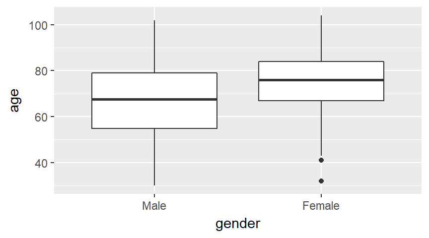

```r
ggplot(whas500, aes(x=gender, y=age)) +
  geom_boxplot()
```

```r
coef_mv <- tidy(cox_mv)
coef_mv
```

```
##           term    estimate   std.error  statistic   p.value    conf.low
## 1          age  0.06692776 0.006195843 10.8020422 0.0000000  0.05478413
## 2 genderFemale -0.06628511 0.140584936 -0.4714951 0.6372872 -0.34182652
##    conf.high
## 1 0.07907139
## 2 0.20925630
```

```r
hr_age <- exp(coef_mv[coef_mv$term=="age", "estimate"])
extrapolated_hr <- hr_age^age_diff
```

Notice that there is a 8.1 year difference between the average ages of men and women. The hazard ratio for age, 1.069, can get extrapolated to a 8.1 year difference by exponentiating. That is 1.069^8.1 = 1.72 which is actually larger than the hazard ratio that we saw for the unadjusted model with just gender.

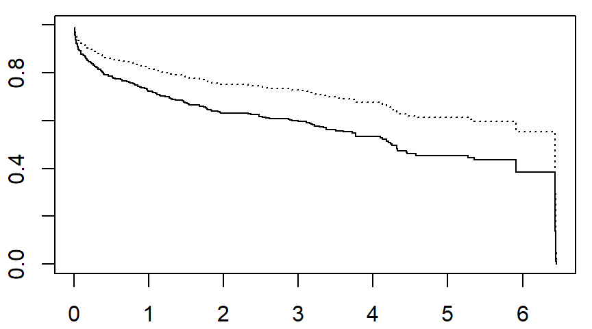

```r
n_unadjusted <-
  data.frame(
    age=gender_means,
    gender=factor(1:2, labels=c("Male", "Female")))
predict_unadjusted <- survfit(cox_mv, newdata=n_unadjusted)
par(mar=c(2.1, 2.1, 0.6, 0.6))
plot(
  predict_unadjusted$time,
  predict_unadjusted$surv[, 2],
  type="s", ylim=c(0,1))
lines(
  predict_unadjusted$time,
  predict_unadjusted$surv[, 1],
  type="s", lty="dotted")
```

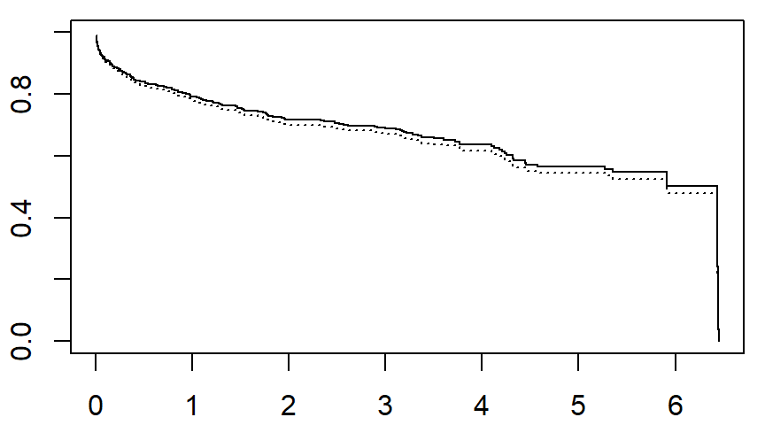

```r
n_adjusted <-
  data.frame(
    age=overall_mean,
    gender=factor(1:2, labels=c("Male", "Female")))
predict_adjusted <- survfit(cox_mv, newdata=n_adjusted)
par(mar=c(2.1, 2.1, 0.6, 0.6))
plot(
  predict_adjusted$time,
  predict_adjusted$surv[, 2],
  type="s", ylim=c(0,1))
lines(
  predict_adjusted$time,
  predict_adjusted$surv[, 1],
  type="s", lty="dotted")
```

```r
whas500$i_female <- as.numeric(whas500$gender=="Female")
cox_bmi <-
  coxph(Surv(time_yrs, fstat=="Dead")~bmi,
    data=whas500)
summary(cox_bmi)
```

```
## Call:
## coxph(formula = Surv(time_yrs, fstat == "Dead") ~ bmi, data = whas500)
##
##   n= 500, number of events= 215
##
##         coef exp(coef) se(coef)      z Pr(>|z|)
## bmi -0.09847   0.90622  0.01475 -6.676 2.46e-11 ***
## ---
## Signif. codes:  0 '***' 0.001 '**' 0.01 '*' 0.05 '.' 0.1 ' ' 1
##
##     exp(coef) exp(-coef) lower .95 upper .95
## bmi    0.9062      1.103    0.8804    0.9328
##
## Concordance= 0.648  (se = 0.021 )
## Rsquare= 0.092   (max possible= 0.993 )
## Likelihood ratio test= 48.33  on 1 df,   p=3.602e-12
## Wald test            = 44.57  on 1 df,   p=2.459e-11
## Score (logrank) test = 44.31  on 1 df,   p=2.807e-11
```

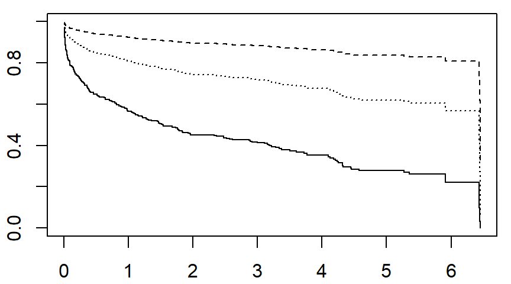

```r
n_bmi <- data.frame(bmi=c(20, 30, 40))
predict_bmi <- survfit(cox_bmi, newdata=n_bmi)
par(mar=c(2.1, 2.1, 0.6, 0.6))
plot(
  predict_bmi$time,
  predict_bmi$surv[, 1],
  type="s", ylim=c(0,1))
lines(
  predict_bmi$time,
  predict_bmi$surv[, 2],
  type="s", lty="dotted")
lines(
  predict_bmi$time,
  predict_bmi$surv[, 3],
  type="s", lty="dashed")
```

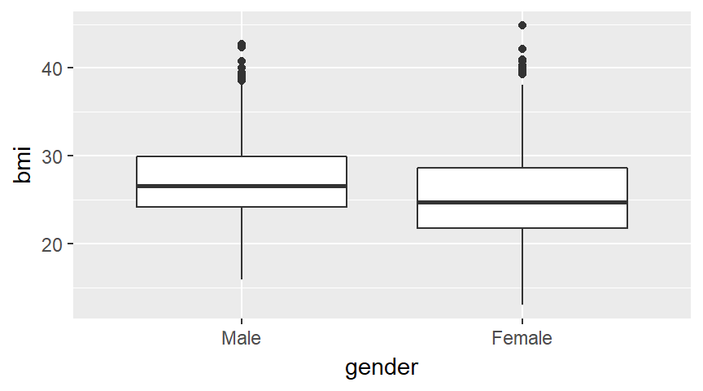

```r
ggplot(data=whas500) +
  geom_boxplot(aes(x=gender, y=bmi))
```

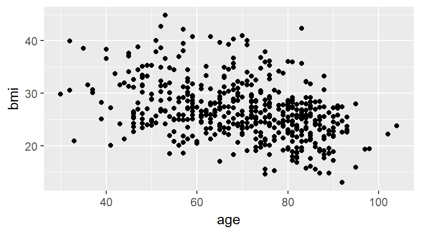

```r
ggplot(data=whas500) +
  geom_point(aes(x=age, y=bmi))
```

```r
cox_bmi_adj <-
  coxph(Surv(time_yrs, fstat=="Dead")~bmi+age+i_female,
    data=whas500)
summary(cox_bmi_adj)
```

```
## Call:
## coxph(formula = Surv(time_yrs, fstat == "Dead") ~ bmi + age +
##     i_female, data = whas500)
##
##   n= 500, number of events= 215
##
##               coef exp(coef)  se(coef)      z Pr(>|z|)
## bmi      -0.042084  0.958789  0.015427 -2.728  0.00637 **
## age       0.060791  1.062677  0.006503  9.348  < 2e-16 ***
## i_female -0.093065  0.911135  0.141085 -0.660  0.50949
## ---
## Signif. codes:  0 '***' 0.001 '**' 0.01 '*' 0.05 '.' 0.1 ' ' 1
##
##          exp(coef) exp(-coef) lower .95 upper .95
## bmi         0.9588      1.043    0.9302    0.9882
## age         1.0627      0.941    1.0492    1.0763
## i_female    0.9111      1.098    0.6910    1.2014
##
## Concordance= 0.739  (se = 0.021 )
## Rsquare= 0.259   (max possible= 0.993 )
## Likelihood ratio test= 150  on 3 df,   p=0
## Wald test            = 128.7  on 3 df,   p=0
## Score (logrank) test = 135.4  on 3 df,   p=0
```

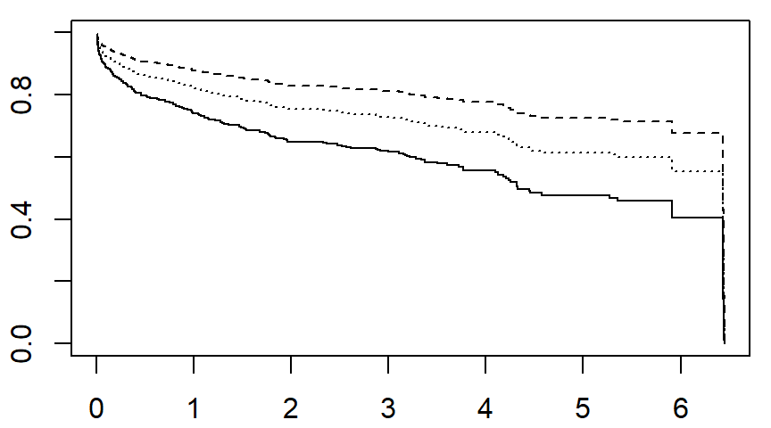

```r
n_bmi <- data.frame(age=overall_mean, i_female=1, bmi=c(20, 30, 40))
predict_bmi <- survfit(cox_bmi_adj, newdata=n_bmi)
par(mar=c(2.1, 2.1, 0.6, 0.6))
plot(
  predict_bmi$time,
  predict_bmi$surv[, 1],
  type="s", ylim=c(0,1))
lines(
  predict_bmi$time,
  predict_bmi$surv[, 2],
  type="s", lty="dotted")
lines(
  predict_bmi$time,
  predict_bmi$surv[, 3],
  type="s", lty="dashed")
```

Look at the interaction.

```r
cox_int1 <-
  coxph(Surv(time_yrs, fstat=="Dead")~age*i_female,
    data=whas500)
summary(cox_int1)
```

```
## Call:
## coxph(formula = Surv(time_yrs, fstat == "Dead") ~ age * i_female,
##     data = whas500)
##
##   n= 500, number of events= 215
##
##                   coef exp(coef)  se(coef)      z Pr(>|z|)
## age           0.078540  1.081707  0.008027  9.785   <2e-16 ***
## i_female      2.333732 10.316375  0.992674  2.351   0.0187 *
## age:i_female -0.030502  0.969958  0.012541 -2.432   0.0150 *
## ---
## Signif. codes:  0 '***' 0.001 '**' 0.01 '*' 0.05 '.' 0.1 ' ' 1
##
##              exp(coef) exp(-coef) lower .95 upper .95
## age              1.082    0.92446    1.0648    1.0989
## i_female        10.316    0.09693    1.4742   72.1926
## age:i_female     0.970    1.03097    0.9464    0.9941
##
## Concordance= 0.734  (se = 0.021 )
## Rsquare= 0.257   (max possible= 0.993 )
## Likelihood ratio test= 148.2  on 3 df,   p=0
## Wald test            = 119.5  on 3 df,   p=0
## Score (logrank) test = 127.7  on 3 df,   p=0
```

```r
whas500$age_centered <- whas500$age-overall_mean
cox_int2 <-
  coxph(Surv(time_yrs, fstat=="Dead")~age_centered*i_female,
    data=whas500)
summary(cox_int2)
```

```
## Call:
## coxph(formula = Surv(time_yrs, fstat == "Dead") ~ age_centered *
##     i_female, data = whas500)
##
##   n= 500, number of events= 215
##
##                            coef exp(coef)  se(coef)      z Pr(>|z|)
## age_centered           0.078540  1.081707  0.008027  9.785   <2e-16 ***
## i_female               0.203288  1.225425  0.174605  1.164    0.244
## age_centered:i_female -0.030502  0.969958  0.012541 -2.432    0.015 *
## ---
## Signif. codes:  0 '***' 0.001 '**' 0.01 '*' 0.05 '.' 0.1 ' ' 1
##
##                       exp(coef) exp(-coef) lower .95 upper .95
## age_centered              1.082     0.9245    1.0648    1.0989
## i_female                  1.225     0.8160    0.8703    1.7255
## age_centered:i_female     0.970     1.0310    0.9464    0.9941
##
## Concordance= 0.734  (se = 0.021 )
## Rsquare= 0.257   (max possible= 0.993 )
## Likelihood ratio test= 148.2  on 3 df,   p=0
## Wald test            = 119.5  on 3 df,   p=0
## Score (logrank) test = 127.7  on 3 df,   p=0
```

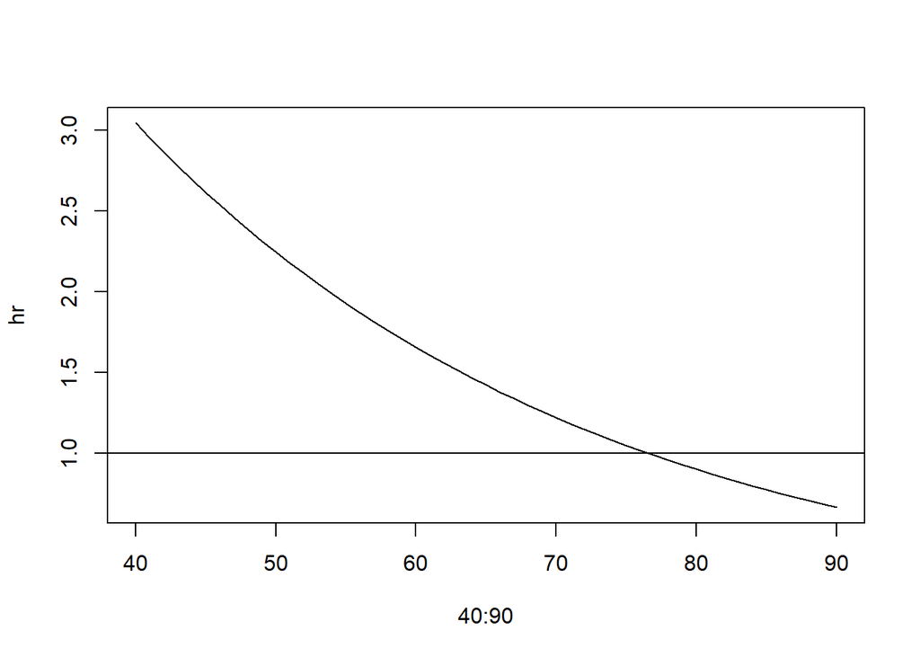

```r
coef_int2 <- tidy(cox_int2)$estimate
hr <- exp(coef_int2[2]+coef_int2[3]*((40:90)-overall_mean))
plot(40:90, hr, type="l")
abline(h=1)
```

You can use a sequence of Wald tests to compare different models for survival.

```r
cox_v1 <- coxph(
  Surv(time_yrs, fstat=="Dead") ~
    gender,
      data=whas500)

cox_v2 <- coxph(
  Surv(time_yrs, fstat=="Dead") ~
    age+gender,
      data=whas500)

cox_v3 <- coxph(
  Surv(time_yrs, fstat=="Dead") ~
    bmi+age+gender,
      data=whas500)

cox_v1                             %>%
  tidy                             %>%
  mutate(lab="gender only")        -> wald_v1

cox_v2                             %>%
  tidy                             %>%
  mutate(lab="age, gender")        -> wald_v2

cox_v3                             %>%
  tidy                             %>%
  mutate(lab="bmi, age, gender")   -> wald_v3

wald_v1                            %>%
  bind_rows(wald_v2)               %>%
  bind_rows(wald_v3)               %>%
  select(lab, term, estimate, p.value) -> wald_all
wald_all
```

```
##                lab         term    estimate     p.value
## 1      gender only genderFemale  0.38151203 0.005555126
## 2      age, gender          age  0.06692776 0.000000000
## 3      age, gender genderFemale -0.06628511 0.637287208
## 4 bmi, age, gender          bmi -0.04208396 0.006374453
## 5 bmi, age, gender          age  0.06079117 0.000000000
## 6 bmi, age, gender genderFemale -0.09306460 0.509487094
```

You use the log partial likelihood and/or the AIC (Akaike Information Criteria) to compare models of different complexity.

AIC = -2 log Likelihood + 2 k.

```r
cox_v1                           %>%
  glance                         %>%
  mutate(lab="gender only")      -> aic1

cox_v2                           %>%
  glance                         %>%
  mutate(lab="gender, age")      -> aic2

cox_v3                           %>%
  glance                         %>%
  mutate(lab="gender, age, bmi") -> aic3

aic1                             %>%
  bind_rows(aic2)                %>%
  bind_rows(aic3)                %>%
  select(lab, logLik, AIC, BIC)  -> aic_all
aic_all
```

```
##                lab    logLik      AIC      BIC
## 1      gender only -1223.522 2449.043 2452.414
## 2      gender, age -1156.138 2316.276 2323.017
## 3 gender, age, bmi -1152.310 2310.620 2320.732
```

There are several residuals available for Cox regression. The Martingale residual is defined as

$M(t_i) = \delta_i - H_0(t_i) e^{X\beta}$

where $\delta_i$ = 0 if censored, 1 if dead.

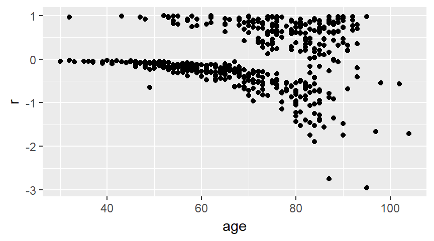

```r
whas500$r <- residuals(cox_v3)
par(mar=c(2.6, 2.6, 0.6, 0.6))
ggplot(whas500, aes(age, r)) +
  geom_point()
```

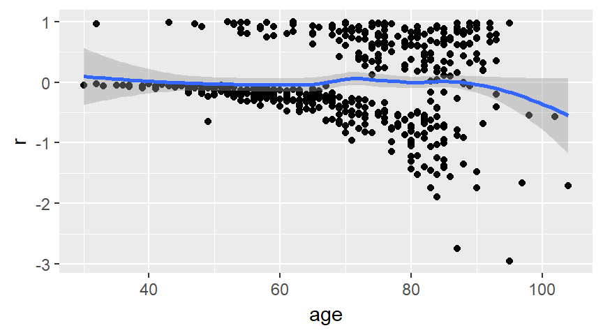

```r
ggplot(data=whas500, aes(age, r)) +
  geom_point() +
  geom_smooth(se=TRUE)
```

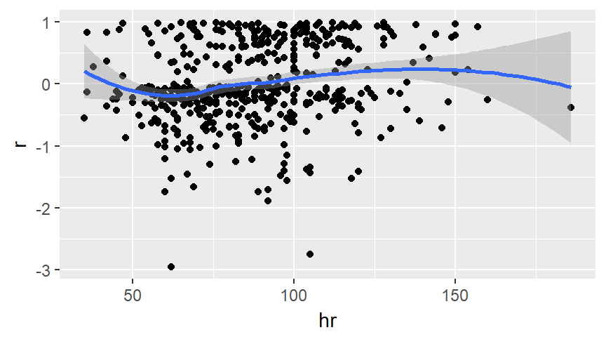

```r
ggplot(data=whas500, aes(hr, r)) +
  geom_point() +
  geom_smooth(se=TRUE)
```

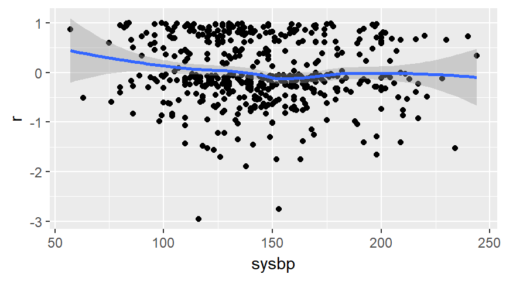

```r
ggplot(data=whas500, aes(sysbp, r)) +
  geom_point() +
  geom_smooth(se=TRUE)
```

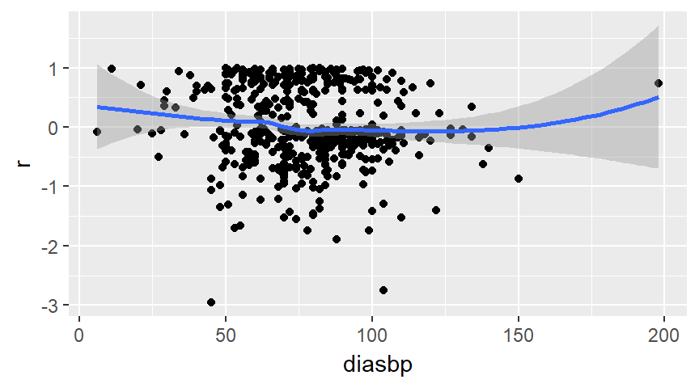

```r
ggplot(data=whas500, aes(diasbp, r)) +
  geom_point() +
  geom_smooth(se=TRUE)
```

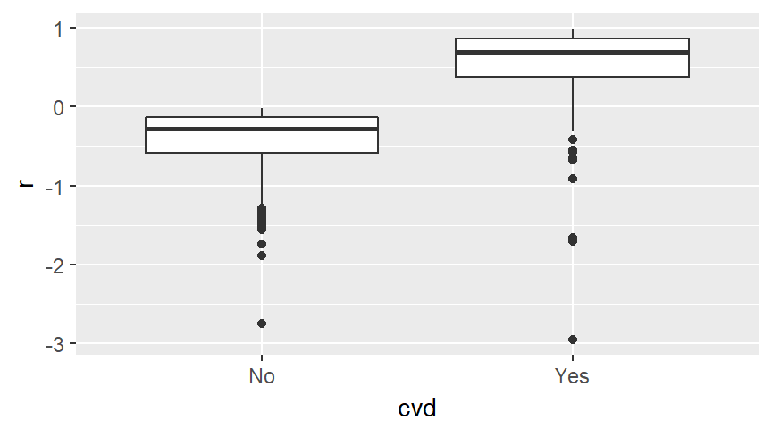

```r
ggplot(data=whas500, aes(cvd, r)) +
  geom_boxplot()
```

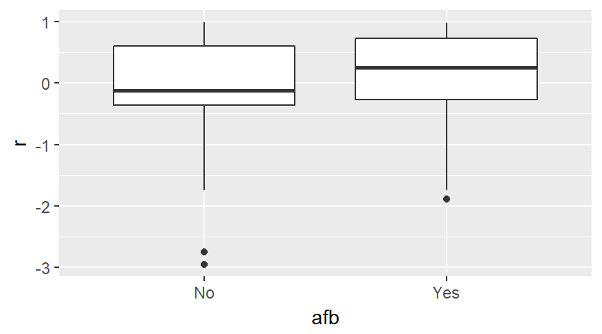

```r
ggplot(data=whas500, aes(afb, r)) +
  geom_boxplot()
```

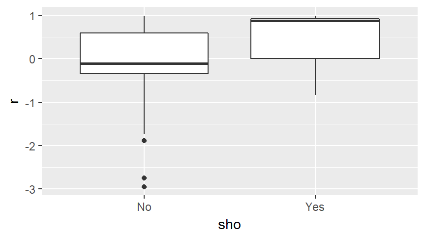

```r
ggplot(data=whas500, aes(sho, r)) +
  geom_boxplot()
```

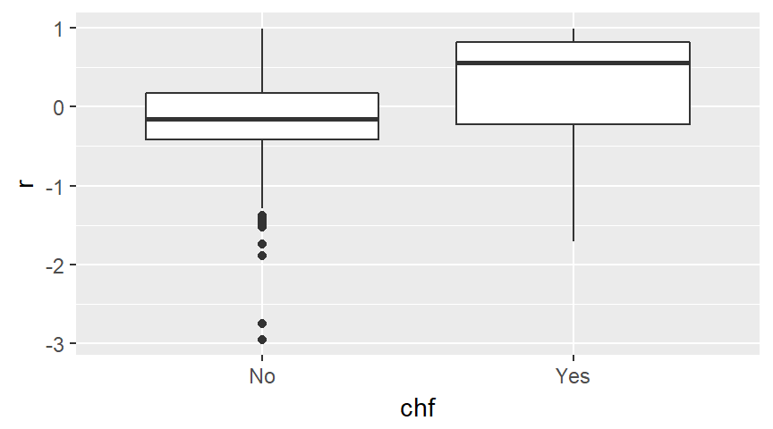

```r
ggplot(data=whas500, aes(chf, r)) +
  geom_boxplot()
```

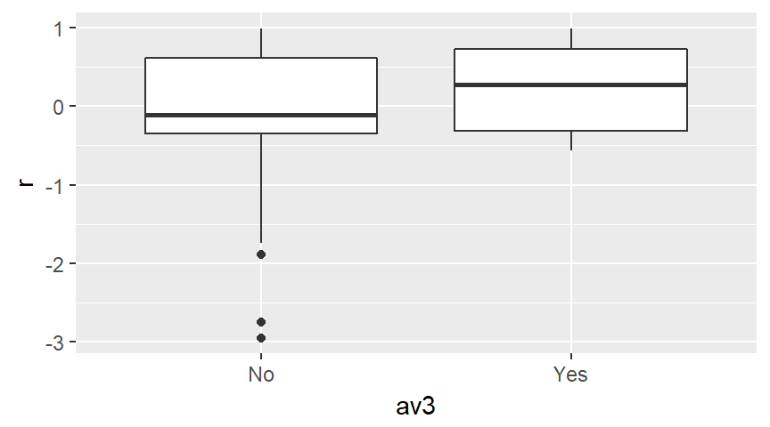

```r
ggplot(data=whas500, aes(av3, r)) +
  geom_boxplot()
```

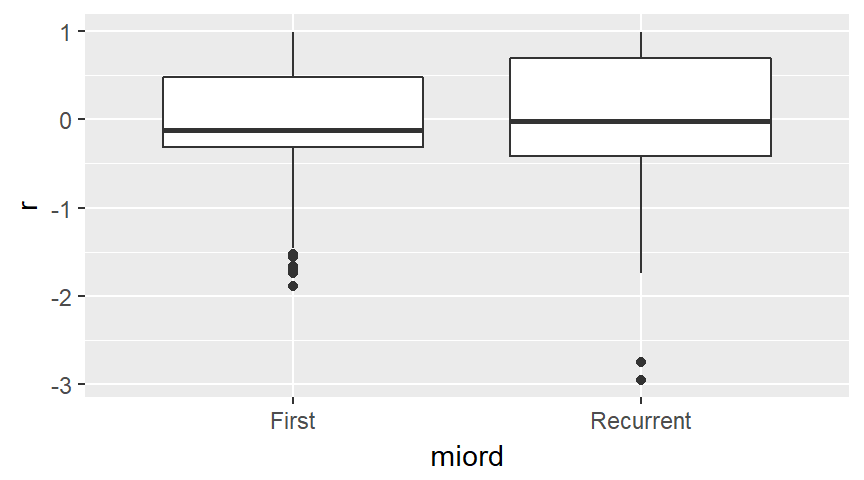

```r
ggplot(data=whas500, aes(miord, r)) +
  geom_boxplot()
```

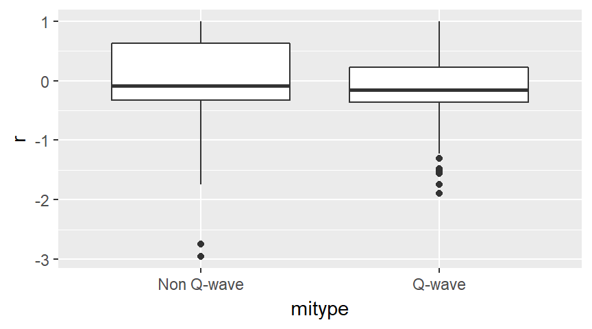

```r
ggplot(data=whas500, aes(mitype, r)) +
  geom_boxplot()
```

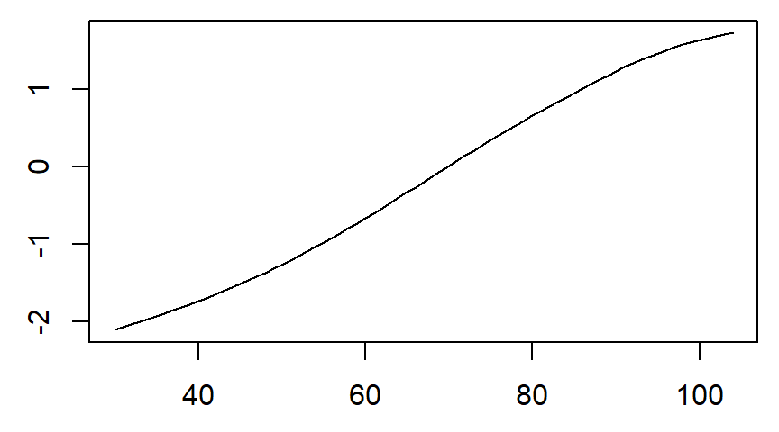

```r
cox_pspline3 <- coxph(
  Surv(time_yrs, fstat=="Dead") ~
    bmi+pspline(age, df=3)+gender,
      data=whas500)

cox_pspline8 <- coxph(
  Surv(time_yrs, fstat=="Dead") ~
    bmi+pspline(age, df=8)+gender,
      data=whas500)

terms_pspline3 <- predict(cox_pspline3, type="terms")
terms_pspline8 <- predict(cox_pspline8, type="terms")
par(mar=c(2.6, 2.6, 0.6, 0.6))
o <- order(whas500$age)
plot(whas500$age[o], terms_pspline3[o ,2], type="l")
```

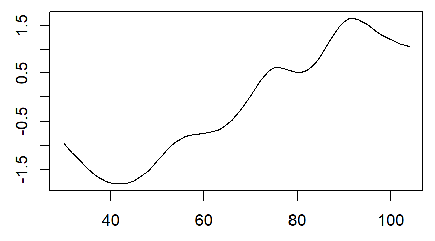

```r
plot(whas500$age[o], terms_pspline8[o ,2], type="l")
```

```r
glance(cox_bmi_adj) %>%
  bind_rows(glance(cox_pspline3)) %>%
  bind_rows(glance(cox_pspline8)) %>%
  mutate(lab=c(
    "linear (df=1)",
    "spline (df=3)",
    "spline (df=8)"))             %>%
  select(lab, logLik, AIC, BIC)   -> compare_splines
compare_splines
```

```
##             lab    logLik      AIC      BIC
## 1 linear (df=1) -1152.310 2310.620 2320.732
## 2 spline (df=3) -1151.288 2308.714 2319.058
## 3 spline (df=8) -1143.118 2302.204 2329.116
```

Testing.

```r
coxph(Surv(time_yrs, fstat=="Dead")~hr, data=whas500)
```

```
## Call:
## coxph(formula = Surv(time_yrs, fstat == "Dead") ~ hr, data = whas500)
##
##       coef exp(coef) se(coef)   z       p
## hr 0.01505   1.01516  0.00269 5.6 2.1e-08
##
## Likelihood ratio test=28.9  on 1 df, p=7.45e-08
## n= 500, number of events= 215
```

```r
coxph(Surv(time_yrs, fstat=="Dead")~sysbp, data=whas500)
```

```
## Call:
## coxph(formula = Surv(time_yrs, fstat == "Dead") ~ sysbp, data = whas500)
##
##           coef exp(coef) se(coef)     z     p
## sysbp -0.00452   0.99549  0.00223 -2.03 0.042
##
## Likelihood ratio test=4.19  on 1 df, p=0.0406
## n= 500, number of events= 215
```

```r
coxph(Surv(time_yrs, fstat=="Dead")~diasbp, data=whas500)
```

```
## Call:
## coxph(formula = Surv(time_yrs, fstat == "Dead") ~ diasbp, data = whas500)
##
##            coef exp(coef) se(coef)     z       p
## diasbp -0.01602   0.98411  0.00328 -4.88 1.1e-06
##
## Likelihood ratio test=23.8  on 1 df, p=1.07e-06
## n= 500, number of events= 215
```

```r
coxph(Surv(time_yrs, fstat=="Dead")~cvd, data=whas500)
```

```
## Call:
## coxph(formula = Surv(time_yrs, fstat == "Dead") ~ cvd, data = whas500)
##
##            coef exp(coef) se(coef)    z    p
## cvdYes 2.19e+01  3.20e+09 2.20e+03 0.01 0.99
##
## Likelihood ratio test=568  on 1 df, p=0
## n= 500, number of events= 215
```

```r
coxph(Surv(time_yrs, fstat=="Dead")~afb, data=whas500)
```

```
## Call:
## coxph(formula = Surv(time_yrs, fstat == "Dead") ~ afb, data = whas500)
##
##         coef exp(coef) se(coef)    z      p
## afbYes 0.540     1.716    0.165 3.26 0.0011
##
## Likelihood ratio test=9.58  on 1 df, p=0.00196
## n= 500, number of events= 215
```

```r
coxph(Surv(time_yrs, fstat=="Dead")~sho, data=whas500)
```

```
## Call:
## coxph(formula = Surv(time_yrs, fstat == "Dead") ~ sho, data = whas500)
##
##         coef exp(coef) se(coef)    z       p
## shoYes 1.190     3.288    0.256 4.65 3.4e-06
##
## Likelihood ratio test=15.8  on 1 df, p=6.87e-05
## n= 500, number of events= 215
```

```r
coxph(Surv(time_yrs, fstat=="Dead")~chf, data=whas500)
```

```
## Call:
## coxph(formula = Surv(time_yrs, fstat == "Dead") ~ chf, data = whas500)
##
##         coef exp(coef) se(coef)    z      p
## chfYes 1.200     3.319    0.138 8.69 <2e-16
##
## Likelihood ratio test=72.3  on 1 df, p=0
## n= 500, number of events= 215
```

```r
coxph(Surv(time_yrs, fstat=="Dead")~av3, data=whas500)
```

```
## Call:
## coxph(formula = Surv(time_yrs, fstat == "Dead") ~ av3, data = whas500)
##
##         coef exp(coef) se(coef)    z    p
## av3Yes 0.479     1.614    0.390 1.23 0.22
##
## Likelihood ratio test=1.31  on 1 df, p=0.252
## n= 500, number of events= 215
```

```r
coxph(Surv(time_yrs, fstat=="Dead")~miord, data=whas500)
```

```
## Call:
## coxph(formula = Surv(time_yrs, fstat == "Dead") ~ miord, data = whas500)
##
##                 coef exp(coef) se(coef)    z      p
## miordRecurrent 0.427     1.532    0.139 3.07 0.0022
##
## Likelihood ratio test=9.14  on 1 df, p=0.0025
## n= 500, number of events= 215
```

```r
coxph(Surv(time_yrs, fstat=="Dead")~mitype, data=whas500)
```

```
## Call:
## coxph(formula = Surv(time_yrs, fstat == "Dead") ~ mitype, data = whas500)
##
##                coef exp(coef) se(coef)     z       p
## mitypeQ-wave -0.660     0.517    0.167 -3.95 7.9e-05
##
## Likelihood ratio test=17.5  on 1 df, p=2.94e-05
## n= 500, number of events= 215
```

Save everything for possible later re-use.

```r
save.image("../../data/class4.RData")
```